# Coding in R Introduction

Christina McCosker, Julia Sunnarborg, Dara Yiu, Alice Hotopp

2024-02-20

## Coding Basics

This document is an R Markdown File - you will be working within a Script. An R script is essentially a text document full of code in the R coding language. Use separate scripts for different analyses, projects, questions, etc.

**To open a new script: File - New File - R Script**

R does not like spaces, it will input “.” as a space in your files/data. In your file and variable names, it is common practice to use “_“,”-“, or”.” instead of a space:

- Example: field_site, phoca-vitulina, seal.health

### Comments

In your script, you can annotate your code with ‘#’ - this makes text following it a “comment” - it is anything that you don’t want to read as code.  
You can also use them to create an outline of your script to easily navigate through, using different amounts of #s.

```r
# This is a comment used to annotate code, break up sections, create an outline, etc.

# Heading ----
## Subheading ----
### Another level ----
```

### Basic Coding

To submit a line of code, use “Ctrl-Enter”. This sends your line of code from your script to the Console.  
Alternatively, you can also type your code into the Console. Try submitting/typing the following matematical functions:

```r
4+5
```

```
## [1] 9
```

```r
10/2
```

```
## [1] 5
```

### Data Structures

There are different ways your data can be stored in R.  
A vector is the basic unit of information in R. Here we will define a vector called “vector” with a number. The <- or = means we will assign something a name. Both will give you the same result:

```r
vector <- 1
vector = 1
```

In your Environment, you will see under “Values” your vector with its contents (1). If you want to print what is in your vector to the Console, type the following:

```r
print(vector)
```

```
## [1] 1
```

You can use c(), where c = concatenate, to create a vector with multiple contents. If you are using sequential numbers, you can use a colon (:). The following will give you the same result:

```r
vector2 <- c(1,2,3)
vector2 <- c(1:3)
```

In these vectors, your data will be stored as different classes:

- numeric: any real number
- integer: integer/whole numbers
- character: strings or individual characters, quoted
- factor: categorical/qualitative variables
- logical: variables composed of true/false
- date: calendar dates and times

You can change the classification of your vectors:

```r
vector2 <- as.numeric(vector2) # shows up as "num"
vector2 <- as.integer(vector2) # shows up as "int"

# Let's try strings (words)
vector3 <- c("hey", "hi", "hello") # automatically classified as character (chr)
vector3 <- as.factor(vector3) # shows up as a factor with 3 levels
vector3 <- as.character(vector3) # back to character

# Let's try logical
binary <- c(1,1,0,0) # shows up as numeric (num)
binary <- as.logical(binary) # converts 1s to true, 0s to false
```

To remove objects/vectors from your Environment, use:

```r
rm(binary)
rm(vector)
rm(vector2)
rm(vector3)

# or to remove everything from your Environment:
rm(list=ls())
```

### Let’s play with some real data

Here we will read in metadata on the bycaught seal skin samples you have all worked on subsampling. First we need to read in your data. For this, you need to know and specify the path to the file you want to read in (modify the code below). This is where file structures on your computer are critical, so be thoughtful about where and how you save and organize R files!

**Note:** R works with CSVs (comma separated values), which is just a different form of an excel spreadsheet. If you have an excel spreadsheet you would like to input into R, use the “Save-As” function to save it as a .csv.

When you import datasheets, you need to name it something in R. Here we will name it “bycatch-data”. Be conscientious and purposeful when naming things in R, or it can get confusing.

```r
bycatch_data <- read.csv("C:/Users/christina_m/Documents/R/Projects/cammen-lab/introduction_to_r/data/BycaughtSampleInventorySubsampled-Fall2023.csv", header = TRUE)

# header = TRUE means that the first line of our csv file contains column headers.
```

This imports your data, creating an object called bycatch_data in your Environment. If you are in your Environment tab, you should see it appear.

In our case, the data is in a dataframe, which looks essentially like a spreadsheet.

### Checking the Data

There are various ways of previewing data in R:

```r
head(bycatch_data) #see the first 6 lines
```

```
##   Trip.ID Haul..  Tag.. PSID Bycaught.Date Bycaught.Date.Format Necropsy.Date
## 1 D65011C      3   6115   NA     2/27/2011            2/27/2011
## 2  L28040      3 DO0295    1     7/27/2013            7/27/2013
## 3 C99017C      1 DO3292    2      7/5/2004             7/5/2004
## 4             NA DO5544   NA
## 5 C84003C      4 DO4482    2      5/6/2004             5/6/2004
## 6  C85003      7   3257    9     4/27/2004            4/27/2004
##   Species Stat.Area Fishery Length Disp Notes  X
## 1      PV       537     100           7       NA
## 2      PV       514     100     83            NA
## 3      PV       513     100     96            NA
## 4      PV        NA                           NA
## 5      PV       521     100          52       NA
## 6      PV        NA     100     87            NA
```

```r
tail(bycatch_data) #see the last 6 lines
```

```
##     Trip.ID Haul..   Tag.. PSID Bycaught.Date Bycaught.Date.Format
## 284 M41014L      3  DO9363    4      04/22/14            4/22/2014
## 285 M41014L      5  DO9304    6      04/22/14            4/22/2014
## 286             NA  DO7672   NA      04/13/13            4/13/2013
## 287 M41014L      5  DO7461    7      04/22/14            4/22/2014
## 288 P53004L      1 DOA0067    1         02/18            2/18/2024
## 289  L74003      2  DO7726    2      04/04/14             4/4/2014
##     Necropsy.Date Species Stat.Area Fishery Length Disp Notes  X
## 284                    HG       537     100    115    1       NA
## 285                    HG       537     100    113    1       NA
## 286                    HG       537 gillnet                   NA
## 287                    HG       537     100    122    1       NA
## 288                    HG       514            110   11       NA
## 289                    HG       526     100    118            NA
```

```r
str(bycatch_data) #view the data structure (e.g., what your columns are and what type of variable they hold)
```

```
## 'data.frame':    289 obs. of  14 variables:
##  $ Trip.ID             : chr  "D65011C" "L28040" "C99017C" "" ...
##  $ Haul..              : int  3 3 1 NA 4 7 1 2 4 NA ...
##  $ Tag..               : chr  "6115" "DO0295" "DO3292" "DO5544" ...
##  $ PSID                : int  NA 1 2 NA 2 9 1 1 1 NA ...
##  $ Bycaught.Date       : chr  "2/27/2011" "7/27/2013" "7/5/2004" "" ...
##  $ Bycaught.Date.Format: chr  "2/27/2011" "7/27/2013" "7/5/2004" "" ...
##  $ Necropsy.Date       : chr  "" "" "" "" ...
##  $ Species             : chr  "PV" "PV" "PV" "PV" ...
##  $ Stat.Area           : int  537 514 513 NA 521 NA 513 514 521 NA ...
##  $ Fishery             : chr  "100" "100" "100" "" ...
##  $ Length              : chr  "" "83" "96" "" ...
##  $ Disp                : chr  "7" "" "" "" ...
##  $ Notes               : chr  "" "" "" "" ...
##  $ X                   : logi  NA NA NA NA NA NA ...
```

```r
View(bycatch_data) #pull up the whole data frame in a new window
summary(bycatch_data) #see a summary of each data column
```

```
##    Trip.ID              Haul..           Tag..                PSID
##  Length:289         Min.   :  1.000   Length:289         Min.   :   1.00
##  Class :character   1st Qu.:  2.000   Class :character   1st Qu.:   1.00
##  Mode  :character   Median :  3.000   Mode  :character   Median :   2.00
##                     Mean   :  4.108                      Mean   :  40.37
##                     3rd Qu.:  4.000                      3rd Qu.:   3.00
##                     Max.   :172.000                      Max.   :8303.00
##                     NA's   :58                           NA's   :68
##  Bycaught.Date      Bycaught.Date.Format Necropsy.Date        Species
##  Length:289         Length:289           Length:289         Length:289
##  Class :character   Class :character     Class :character   Class :character
##  Mode  :character   Mode  :character     Mode  :character   Mode  :character
##
##
##
##
##    Stat.Area       Fishery             Length              Disp
##  Min.   :  5.0   Length:289         Length:289         Length:289
##  1st Qu.:514.0   Class :character   Class :character   Class :character
##  Median :522.0   Mode  :character   Mode  :character   Mode  :character
##  Mean   :528.1
##  3rd Qu.:537.0
##  Max.   :637.0
##  NA's   :67
##     Notes              X
##  Length:289         Mode:logical
##  Class :character   NA's:289
##  Mode  :character
##
##
##
##
```

```r
colnames(bycatch_data) #see the column names
```

```
##  [1] "Trip.ID"              "Haul.."               "Tag.."
##  [4] "PSID"                 "Bycaught.Date"        "Bycaught.Date.Format"
##  [7] "Necropsy.Date"        "Species"              "Stat.Area"
## [10] "Fishery"              "Length"               "Disp"
## [13] "Notes"                "X"
```

You can call a specific column with the $ symbol: dataframe_name$column. This is an easy way to QA/QC the data. For example, using unique() will provide a non-redundant list of values in the column of interest:

```r
unique(bycatch_data$Species)
```

```
## [1] "PV" "Pv" ""   "HG"
```

Here you can see:

- At least one line is missing a species designation (““)
- Pv is entered inconsistently (PV and Pv)

This leaves you with some options:

- If you are in the data QA/QC process, y ou can locate these problematic lines. Often, when data is missing for real, we designate something like “unknown” or “missing” or NA to denote that the data is truly missing and is not a typo or spreadsheet error.
- If the data spreadsheet is finalized, we can deal with these errors in the code, see below.

```r
unique(bycatch_data$Tag..) # at least one entry of Tag data is missing
```

```
##   [1] "6115"     "DO0295"   "DO3292"   "DO5544"   "DO4482"   "3257"
##   [7] "3291"     "DO5895"   "DO4481"   "DO8057"   "DO8950"   "5320"
##  [13] "DO0028"   "DO5894"   "DO5634"   "DO0067"   "DO1683"   "DO9837"
##  [19] "DO0069"   "DO9894"   "DOA0198"  "DO8158"   "DO9375"   "DO8985"
##  [25] "DO0279"   "8583"     "DOA0260"  "DO8521"   "DO8193"   "DO0671"
##  [31] "DO5711"   "DO6688"   "7901"     "DO7826"   "DO6564"   "DO7965"
##  [37] "DO0827"   "DO5900"   "DO5021"   "DO5898"   "DO5177"   "6471"
##  [43] "DO0673"   "DO7450"   "5259"     "DO5256"   "DO5841"   "DO0513"
##  [49] "DO5176"   "5318"     "DO5317"   "DO6773"   "DO5791"   "DO8511"
##  [55] "DO8534"   "DOA1626"  "DO8313"   "8303"     "7961"     "DO8058"
##  [61] "DO8320"   "8534"     "5260"     "DO8312"   "8166"     "DO5137"
##  [67] "7954"     "5814"     "DO1759"   "DO6032"   "3260"     "DO1860"
##  [73] "DO9662"   "DOA0029"  "DOA0031"  "DO9887"   "DO9320"   "DO9319"
##  [79] "DO8065"   "8535"     "DO8748"   "DO8883"   "DO8983"   "8523"
##  [85] "8511"     "3252"     "DO7866"   "DO8068"   "DO7237"   "7405"
```

[output cut: 31 more lines]

```r
unique(bycatch_data$Length) # inconsistent nomenclature here too (usually my column name is "length_cm" and the values are all numeric or not_available)
```

```
##  [1] ""        "83"      "96"      "87"      "107"     "149"     "94"
##  [8] "92"      "113"     "100"     "122"     "86 cm"   "104"     "120"
## [15] "89"      "118"     "90"      "88"      "127"     "97"      "78"
## [22] "115"     "110"     "108"     "104 cm"  "91 cm "  "90 cm"   "85"
## [29] "89cm"    "126"     "101"     "146"     "151"     "135"     "109"
## [36] "85 cm"   "105"     "105 cm"  "116"     "133"     "142"     "95"
## [43] "103"     "119cm"   "112"     "114"     "103cm"   "98"      "126 cm "
## [50] "105cm"   "101cm"   "145"     "99"      "52"      "110 cm"  "121"
## [57] "128cm"   "95cm"    "46 in"   "137"     "11"      "130"     "197"
## [64] "106"     "102"     "123cm"   "126 cm"  "131"     "48"      "120 cm"
## [71] "130 cm"  "113.2"   "128"     "61 in"   "81cm"    "160"     "124"
## [78] "130.3"   "139cm"   "117"     "91 (TL)" "123"     "220"     "129"
## [85] "119 cm"  "138cm"   "132"     "138"     "167"     "91"      "126.7"
```

```r
unique(bycatch_data$Disp) # also all over the place
```

```
##  [1] "7"           ""            "52"          "dead"        "25"
##  [6] "12"          "28"          "11"          "1"           "5"
## [11] "fresh dead"  "ins tak. "   "inc teler? " "DF"
```

```r
unique(bycatch_data$Haul..) # you can see an array of numbers and an NA
```

```
##  [1]   3   1  NA   4   7   2   6   5  14   8  35  16 172  15  37  11  10
```

### Data Cleanup

We can use some R packages to cleanup our dataframe. An R package is essentially a package of code and functions written by someone to make our lives easier in R.

“tidyverse” is a great set of packages that helps make data manipulation easier.

The first time you use any new package, you have to install it. Install packages by using Tools - Install Packages…, or by heading to the Packages Tab and clicking Install, or by running this line:

```r
install.packages("tidyverse") #or in the "packages" tab to the right.
```

Once it is installed, you just have to load it into your workspace each time you open RStudio:

```r
library(tidyverse)
```

If we want to summarise some data, first we have to make some cleaner dataframes. Here we are creating a new object called “bycatch_data_clean” that is an exact copy of “bycatch_data” that we can then manipulate without losing our original dataframe.

```r
bycatch_data_clean <- bycatch_data
```

We will employ the pipe operator (|> or %>%), which just means – take the data, and then subject it to the next command:

```r
bycatch_data_clean <-
  bycatch_data |>
  mutate(Species=gsub("Pv", "PV", Species))
```

We just created our new object bycatch_data_clean by using bycatch_data and using the mutate function. The mutate function manipulates the dataframe - we are telling it to name a column Species (which is already present, so our output will replace the original column). We are using the gsub function to replace “Pv” with “PV” in the Species column.  
Functions in R work similarly to functions in excel, where you specify objects, functions, code, etc. for different parts of the function. In the Help tab, you can type “gsub” to learn more about the gsub function. The help tab will tell us what we need to specify for the function to work, and provide examples. For gsub, we specify the pattern we want to look for (Pv), the string we want to replace the pattern with (PV), and the object within which to do this replacement (column Species). Because we specified we are using bycatch_data above, we don’t need to specify bycatch_data$Species here.  
Let’s check if it worked:

```r
unique(bycatch_data_clean$Species)
```

```
## [1] "PV" ""   "HG"
```

We can string together a whole bunch of piped operations with some common commands. We are assuming that anything saying gillnet is gillnet bycatch.

```r
bycatch_data_clean <-
  bycatch_data |>
  mutate(Species = gsub("Pv", "PV", Species)) |> # what we did above, but now we are adding on!
  filter(Species == "PV" | Species == "HG") |> # choose rows that have an entry for species PV OR HG (the line | means OR)
  mutate(Fishery = gsub("Gillnet", "gillnet", Fishery)) |>
  mutate(Fishery = gsub("gillnet ", "gillnet", Fishery)) |>
  mutate(Fishery = gsub("gillnet/anchor sink", "gillnet", Fishery)) |>
  mutate(Fishery = gsub("gillnet/sink fixed", "gillnet", Fishery)) |>
  mutate(Fishery = gsub("100 \\(gillnet\\)", "gillnet", Fishery)) |>  #the parentheses in the code pose an extra problem \
  filter(Fishery != "") # choose rows where the fishery column is NOT empty (the ! means NOT)
```

Always check the commands did what you wanted them to do:

```r
unique(bycatch_data_clean$Species)
```

```
## [1] "PV" "HG"
```

```r
unique(bycatch_data_clean$Fishery)
```

```
##  [1] "100"         "50"          "gillnet"     "108"         "117"
##  [6] "trow 1 "     "GIV"         "Anchor Sink" "370"         "trawl"
## [11] "41"          "2"           "137"         "ONS"         "170"
## [16] "110"         "0"
```

```r
View(bycatch_data_clean)
```

### Making Data Summaries

Let’s say we want to create a summary of bycatch from each fishery:

```r
fishery_summary <-
  bycatch_data_clean |>
  group_by(Species, Fishery) |>
  summarise(
    count = n()
  )
```

And we want to visualize that data:

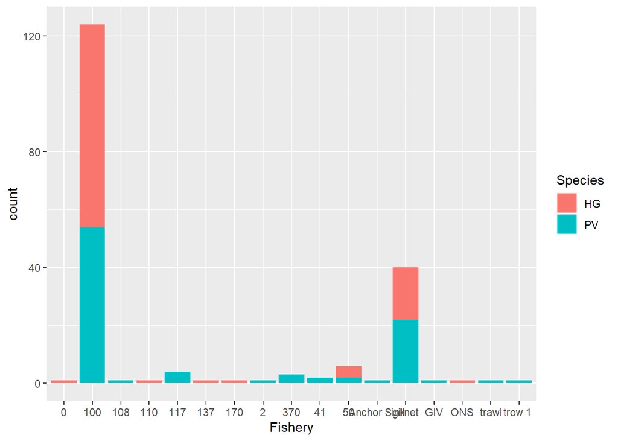

```r
ggplot(fishery_summary, aes(x=Fishery, y=count, fill = Species)) +
  geom_bar(stat="identity")
```

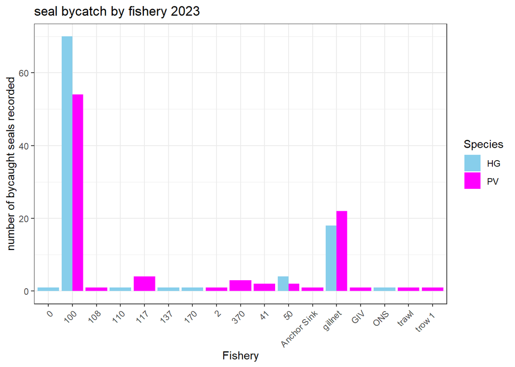

```r
# We can add various elements with the + symbol to make the plot look better
ggplot(fishery_summary, aes(x=Fishery, y=count, fill = Species)) +
  geom_bar(stat="identity", position ="dodge") +
  scale_fill_manual(values = c("skyblue", "magenta"))+
  theme_bw()+
  theme(axis.text.x = element_text(angle = 45, hjust = 1)) +
  labs(y="number of bycaught seals recorded", title = "seal bycatch by fishery 2023")
```

Notes about ggplot

- ggplot works by layering elements of a graph, and that makes it very fun and customizable!
- There are two essential pieces: ggplot() + geom_something()
  - In the ggplot() parentheses, we identify the object that holds our data, and designate the x and y axes as well as visual elements like what variable we want the colors to correspond to
  - The geom_something element tells it what kind of plot we are making (the geometry)
    - In our case, we are making a bar plot so we give it geom_bar()
- Other options include geom_boxplot, geom_point, or geom_line
  - Some geometries might have additional pieces to fill in
  - Like in our case we add stat=“identity” to make the height of our bar be our y variable
- We can then keep layering to make the graph extra nice looking
- We added some grouping to our bars with position = “dodge”
- We also chose our colors, added a theme (notice the background change), and added labels/titles

Let’s make a different plot, plotting the # of each species bycaught per year. To do this, we are using str_sub function from stringr package to get the last 4 characters from our date column (formatted as date in GoogleSheets)

```r
species_summary <-
  bycatch_data_clean %>%
  mutate(Year = str_sub(Bycaught.Date.Format, start=-4, end=-1)) %>%
  group_by(Species, Year) %>%
  summarise(count=n())
```

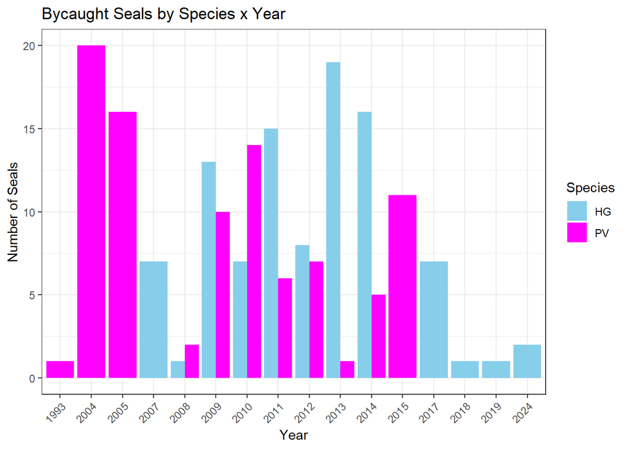

```r
ggplot(species_summary, aes(x=Year, y=count, fill = Species)) +
  geom_bar(stat="identity", position ="dodge") +
  scale_fill_manual(values = c("skyblue", "magenta"))+
  theme_bw()+
  theme(axis.text.x = element_text(angle = 45, hjust = 1)) +
  labs(y="Number of Seals", title = "Bycaught Seals by Species x Year")
```